# Marginal Plots & Annotations

Gurkanwar Singh (gs3006)

November 6, 2018

## 1. Marginal Plots

### 1.1. Introduction

In a scatterplot, it is sometimes useful to check the distribution of variables of the X and Y axis. Here Marginal Plots come to the rescue! Using marginal plots, we can add histogram or density plots to the X and Y axes of a scatterplot. The only problem is Marginal plots are not natively supported by ggplot2. But worry not! The `ggExtra` package (created by Dean Attali) allows one to easily add marginal plots to our usual `ggplot2` scatterplots.

### 1.2. Installation

The `ggExtra` package is avaialable on CRAN and can be installed directly.

```r
#install
#install.packages("ggExtra")

# library
library(tidyverse)
library(ggExtra)
```

### 1.3. How it works

Following is an example of how to add marginal histograms, density curves and boxplots to the scatterplots.

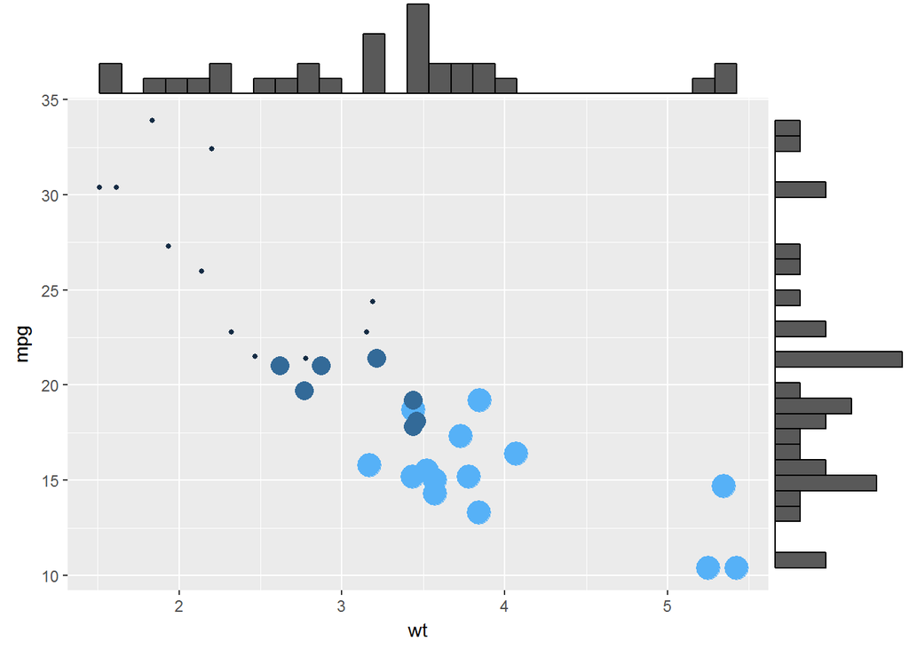

```r
# The mtcars dataset is proposed in R
#head(mtcars)

# classic plot :
g = ggplot(mtcars, aes(x=wt, y=mpg, color=cyl, size=cyl)) +
      geom_point() +
      theme(legend.position="none")

# with marginal histogram
ggMarginal(g, type="histogram")
```

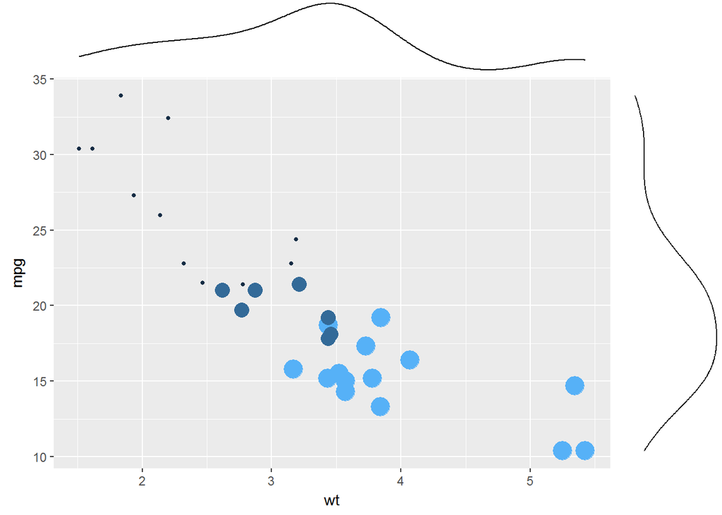

```r
# marginal density
ggMarginal(g, type="density")
```

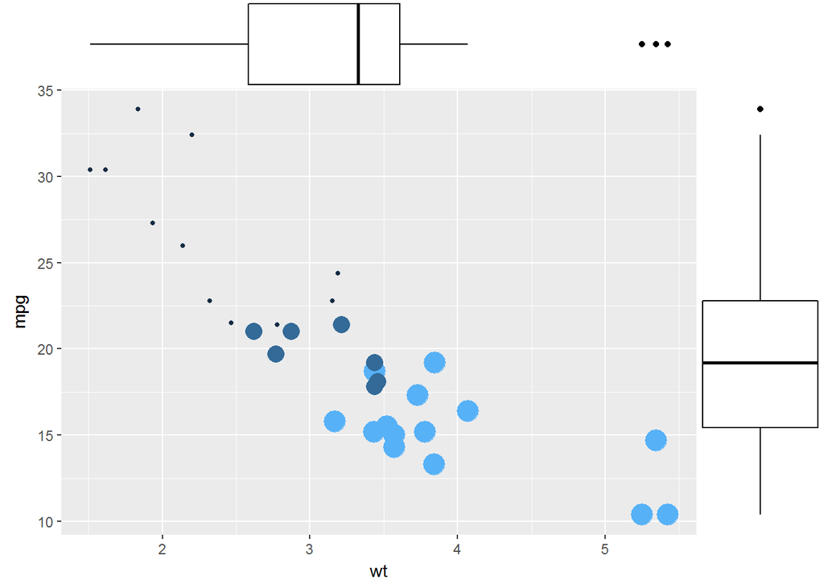

```r
# marginal boxplot
ggMarginal(g, type="boxplot")
```

We can customize the margins’ width or their features, and we can show the margin for only one axis.

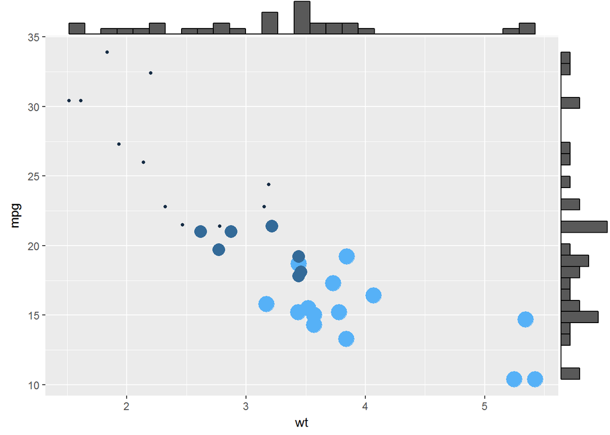

```r
# Set relative size of marginal plots (main plot 10x bigger than marginals)
ggMarginal(g, type="histogram", size=10)
```

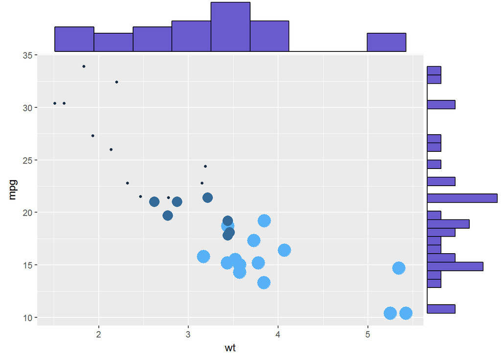

```r
# Custom marginal plots:
ggMarginal(g, type="histogram", fill = "slateblue", xparams = list(  bins=10))
```

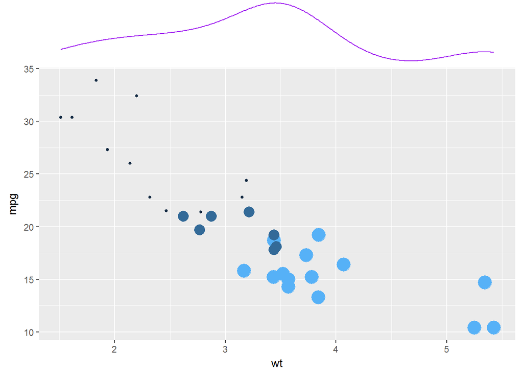

```r
# Show only marginal plot for x axis
ggMarginal(g, margins = 'x', color="purple", size=4)
```

## 2. Annotations

### 2.1. Introduction

Once our ggplot2 chart is ready, we often need to annotate it to provide more information or highlight a specific part. We can do this easily using the annotate() function.

### 2.2. How it works

In the first example, let’s add 2 text elements on the plot. We can also adjust the angle of the annotations. If you want to add text from a data.frame, you need to add geom_text!

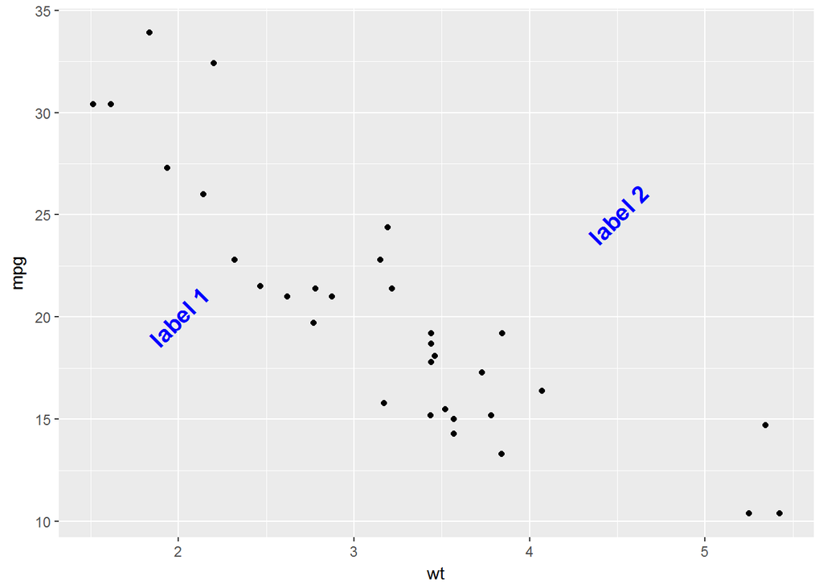

```r
# basic graph
g <- ggplot(mtcars, aes(x = wt, y = mpg)) + geom_point()

# Add text on a specific positions:
g + annotate("text", x = c(2,4.5), y = c(20,25), label = c("label 1", "label 2") , color="blue", size=5 , angle=45, fontface="bold")
```

Below are 3 examples showing how to add rectangles, segments and arrows to your plot.

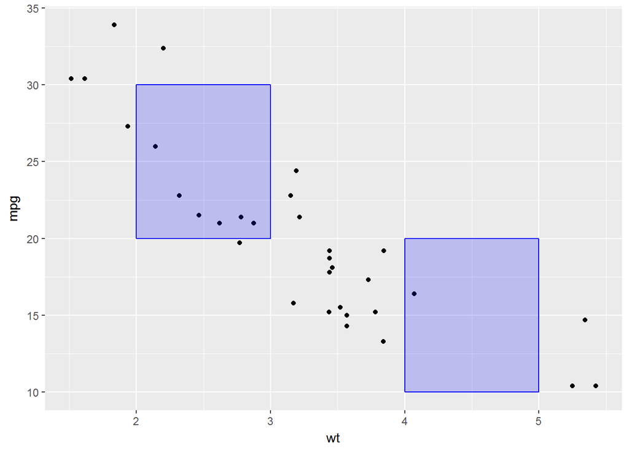

```r
# Add rectangles
g + annotate("rect", xmin=c(2,4), xmax=c(3,5), ymin=c(20,10) , ymax=c(30,20), alpha=0.2, color="blue", fill="blue")
```

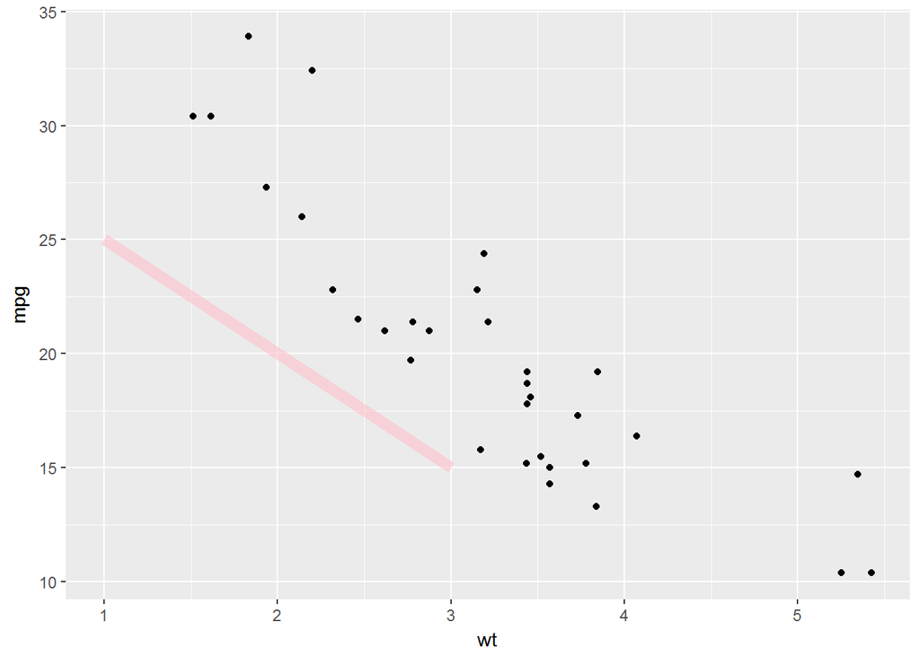

```r
# Add segments
g + annotate("segment", x = 1, xend = 3, y = 25, yend = 15, colour = "pink", size=3, alpha=0.6)
```

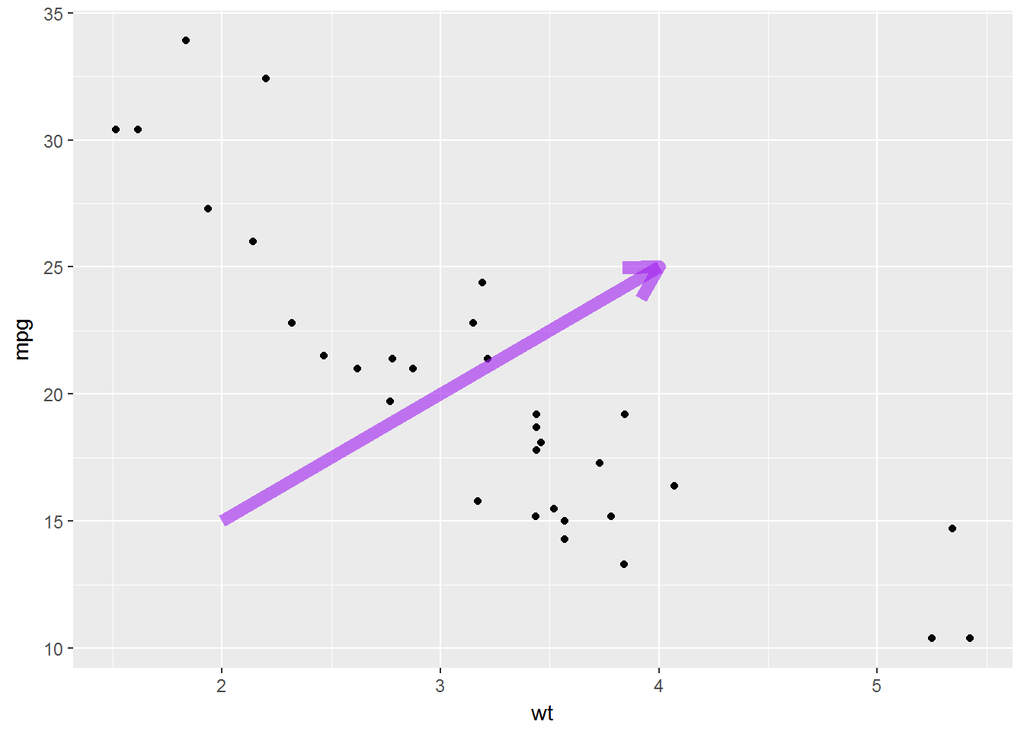

```r
# Add arrow
g + annotate("segment", x = 2, xend = 4, y = 15, yend = 25, colour = "purple", size=3, alpha=0.6, arrow=arrow())
```

We can also add a point and a range around a plot with the “pointrange” geom as follows:

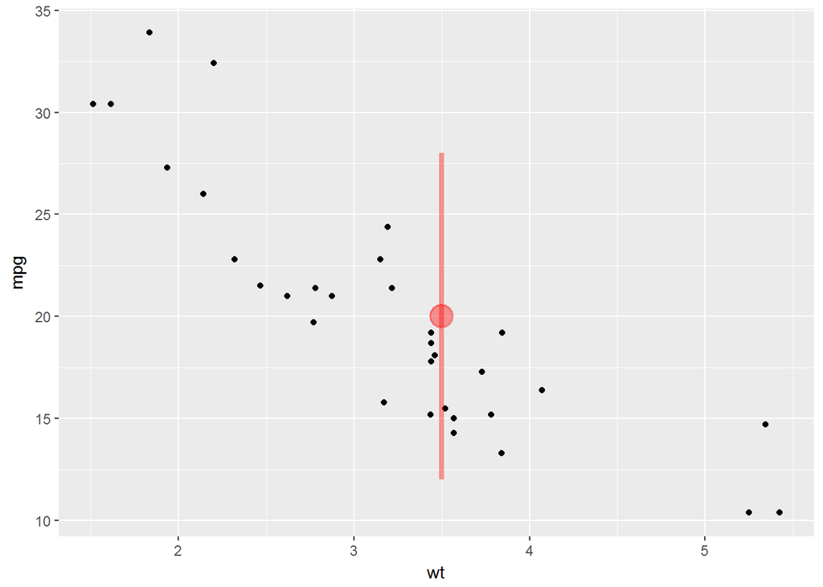

```r
# Add point and range
g + annotate("pointrange", x = 3.5, y = 20, ymin = 12, ymax = 28, colour = "red", size = 1.5, alpha=0.4)
```

### 2.3. Ablines

If you need to add ablines, do not use annotate! You can use geom_hline and geom_vline for that purpose.

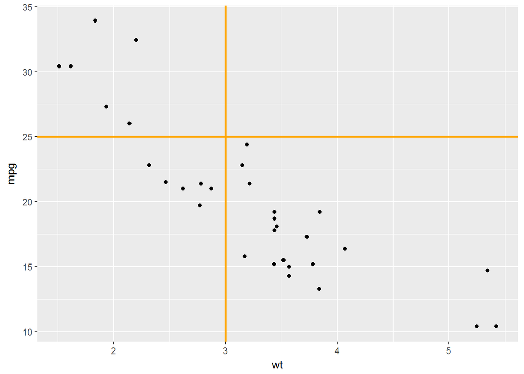

```r
# Add abline
g + geom_hline(yintercept=25, color="orange", size=1) + geom_vline(xintercept=3, color="orange", size=1)
```

## References:

1. https://www.r-graph-gallery.com/portfolio/ggplot2-package/
2. https://www.r-bloggers.com/ggextra-r-package-for-adding-marginal-histograms-to-ggplot2-2/